# Time series data

Vatsal Jani

2023-10-09

```r
library(readr)
Time_series_data <- read_csv("Time series data.csv")
View(Time_series_data)
library(fpp)
library(fpp2)
library(TTR)
```

```r
attributes(Time_series_data)
```

```
## $row.names
##  [1]  1  2  3  4  5  6  7  8  9 10 11 12 13 14 15 16 17 18 19 20 21 22 23 24 25
## [26] 26 27 28 29 30 31 32 33 34 35 36 37 38 39 40 41 42 43 44 45 46 47 48 49 50
## [51] 51 52 53 54 55 56 57 58 59 60 61 62 63 64
##
## $names
## [1] "Period"
## [2] "Revenue"
## [3] "Sales_quantity"
## [4] "Average_cost"
## [5] "The_average_annual_payroll_of_the_region"
##
## $spec
##
## $problems
## <pointer: 0x00000125dec144e0>
##
## $class
## [1] "spec_tbl_df" "tbl_df"      "tbl"         "data.frame"
```

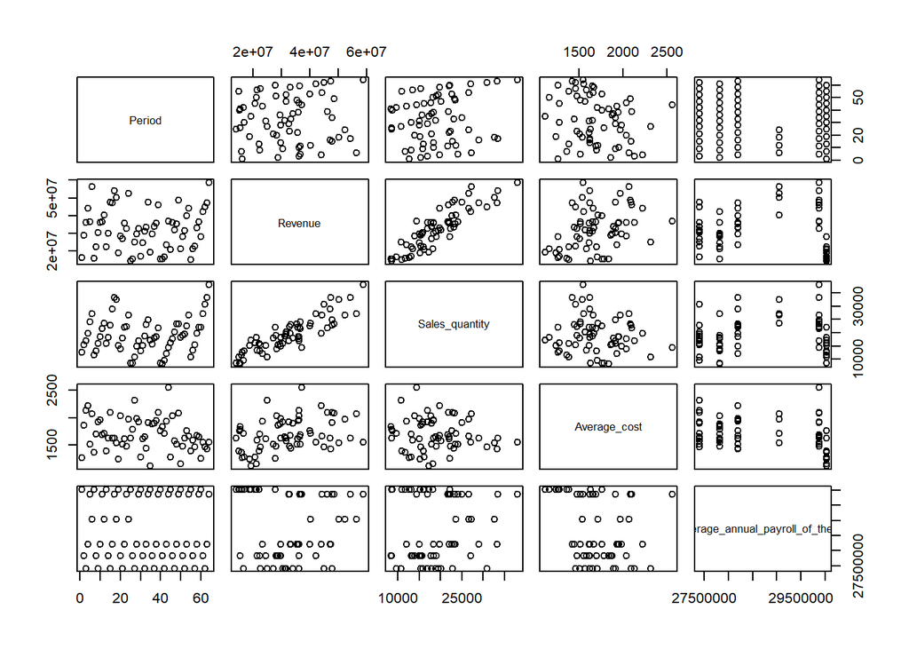

```r
plot(Time_series_data)
```

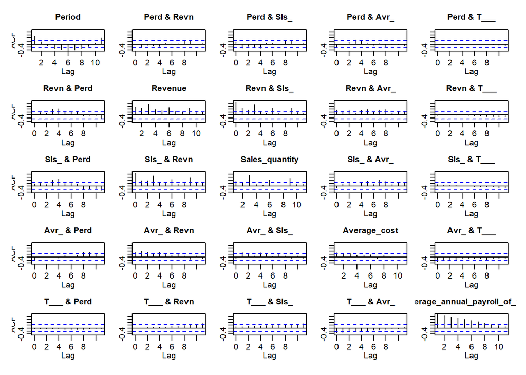

```r
Acf(Time_series_data)
```

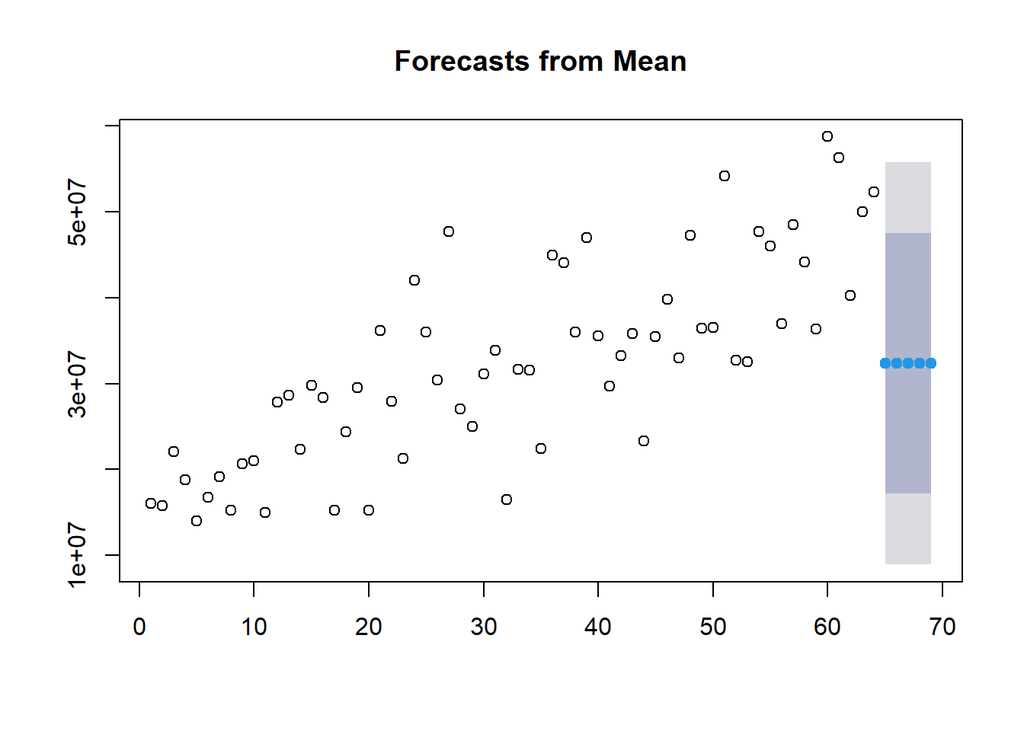

```r
mean_revenue <- meanf(Time_series_data$Revenue,5)
plot(mean_revenue)
```

#Naive method

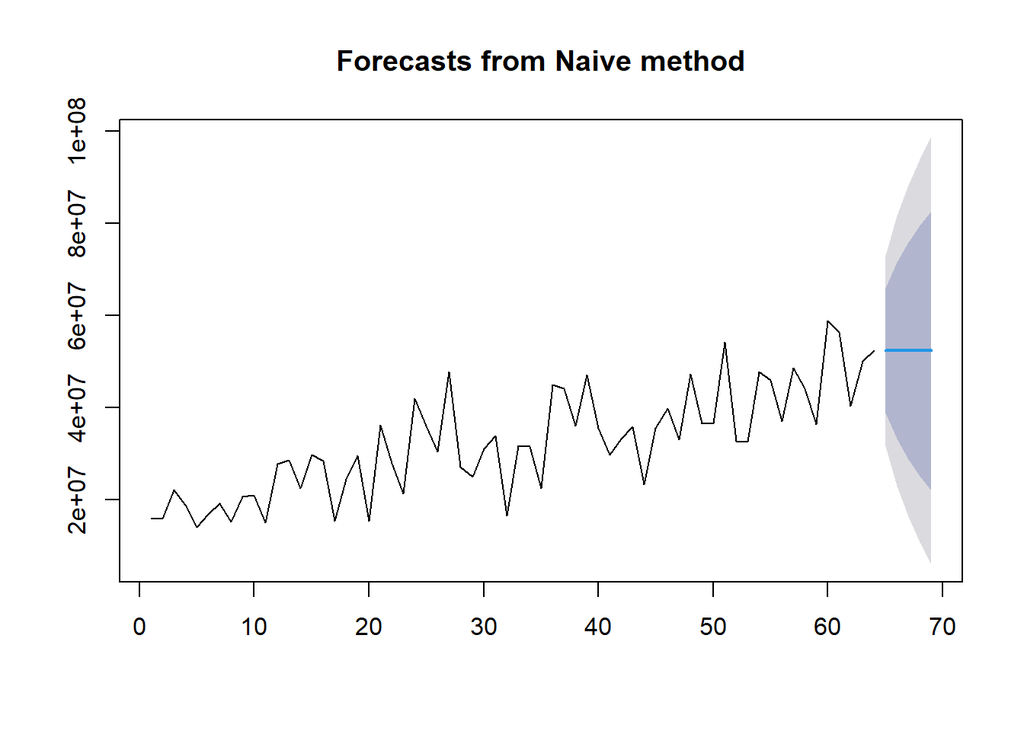

```r
naive_revforecast <- naive(Time_series_data$Revenue,5)
plot(naive_revforecast)
```

#Naive method does not work well because forecast is increasing every year and foreacsts cannot be set on the basis of last value due to randomness of data.

# Seasonal Naive

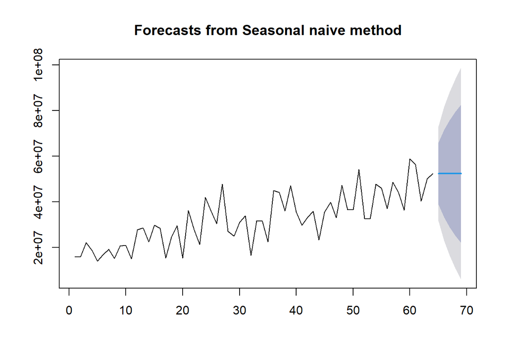

```r
snaive_revforecast <- snaive(Time_series_data$Revenue,5)
plot(snaive_revforecast)
```

#Seasonal Naive method does not work well because there is no seasonality in data. Forecast is increasing every year.

# Random Walk

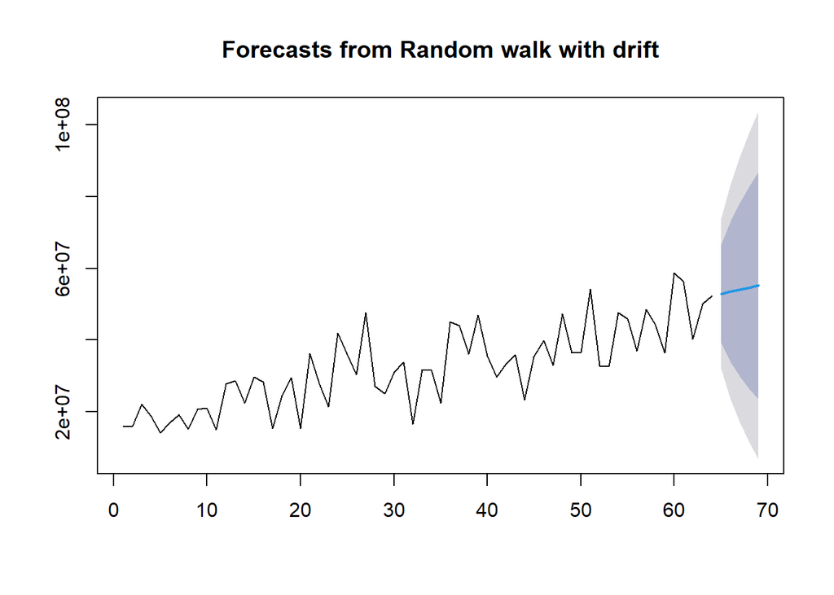

```r
rwf_revforecast <- rwf(Time_series_data$Revenue,5)
rwf_revforecast <- rwf(Time_series_data$Revenue,5, drift=TRUE)
plot(rwf_revforecast)
```

#Random walk with method seems to be a good model for this data because it allows the forecasts to increase over time, where the amount of change over time is set to be the average change seen in the historical data.

# Moving Averages

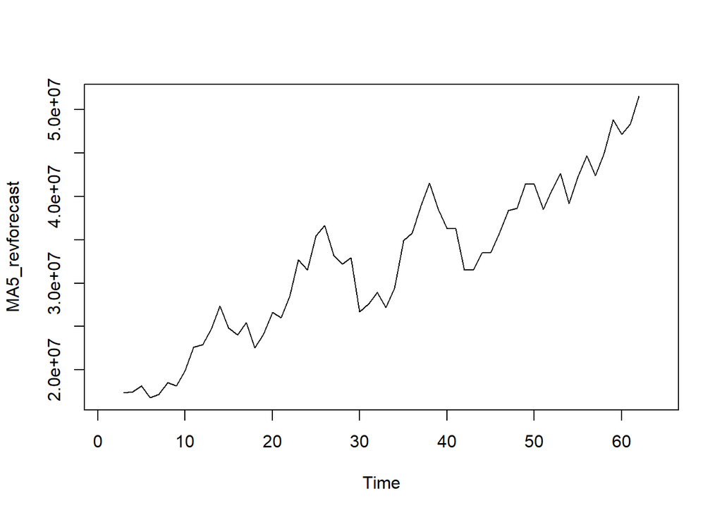

```r
MA5_revforecast <- ma(Time_series_data$Revenue,order=5)
MA9_revforecast <- ma(Time_series_data$Revenue,order=9)
plot(MA5_revforecast)
```

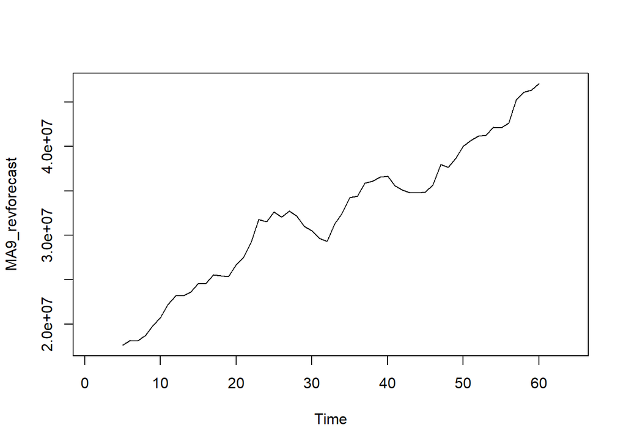

```r
plot(MA9_revforecast)
```

#Trend cycle for MA5 and MA9 is smoother than original data.As the order of moving average is increased, line gets smoother. This method eliminates some of the randomness observed with other models.

# plot all in a single chart

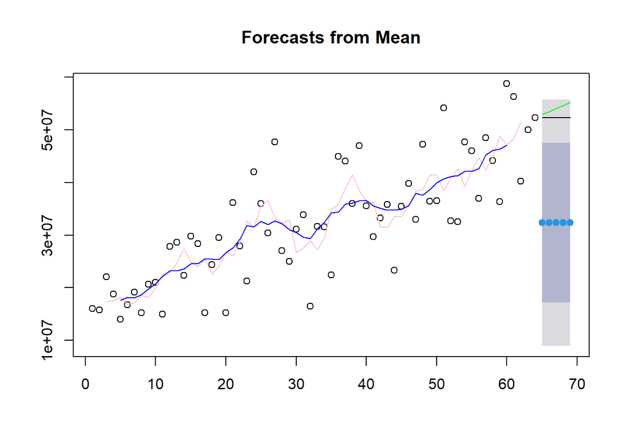

```r
plot(mean_revenue)
lines(naive_revforecast$mean,col="red")
lines(rwf_revforecast$mean,col="green")
lines(snaive_revforecast$mean,col="black")
lines(MA5_revforecast,col="Pink")
lines(MA9_revforecast,col="Blue")
```

#MA9 , MA5 and Random walk models seem to be good fits.

# Decomposition

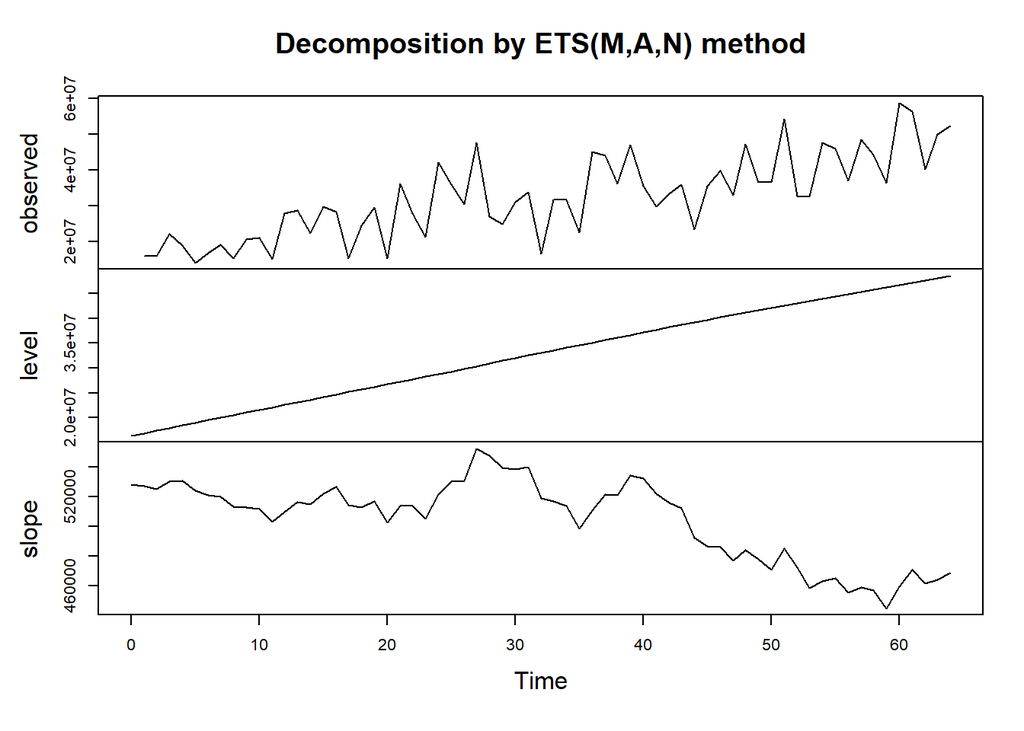

```r
ets_revforecast <- ets(Time_series_data$Revenue)
plot(ets_revforecast)
```

```r
attributes(ets_revforecast)
```

```
## $names
##  [1] "loglik"     "aic"        "bic"        "aicc"       "mse"
##  [6] "amse"       "fit"        "residuals"  "fitted"     "states"
## [11] "par"        "m"          "method"     "series"     "components"
## [16] "call"       "initstate"  "sigma2"     "x"
##
## $class
## [1] "ets"
```

```r
ets_revforecast$mse
```

```
## [1] 5.132133e+13
```

#Forecast

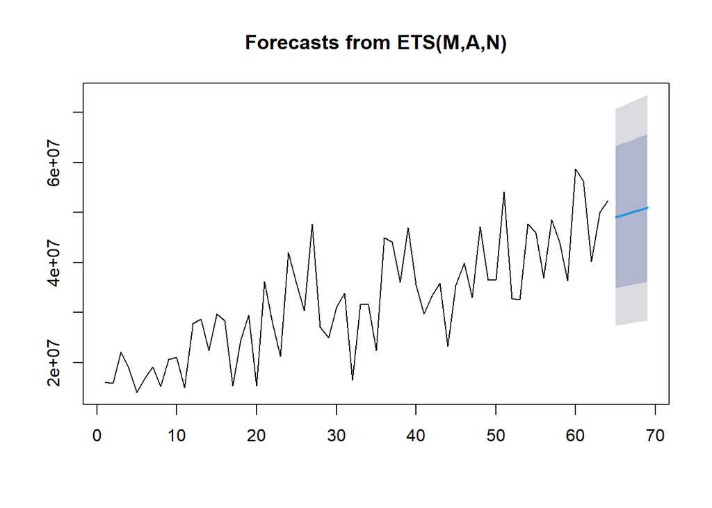

```r
revforecast_ets_1 <- forecast.ets(ets_revforecast, h=5)
plot(revforecast_ets_1)
revforecast_ets_2 <- forecast(ets_revforecast, h=5)
plot(revforecast_ets_2)
```

[output not shown]

```r
accuracy(naive_revforecast)
```

```
##                    ME     RMSE     MAE       MPE     MAPE MASE       ACF1
## Training set 576359.1 10601914 8463439 -4.091482 27.90907    1 -0.4678774
```

```r
accuracy(snaive_revforecast)
```

```
##                    ME     RMSE     MAE       MPE     MAPE MASE       ACF1
## Training set 576359.1 10601914 8463439 -4.091482 27.90907    1 -0.4678774
```

```r
accuracy(rwf_revforecast)
```

```
##                        ME     RMSE     MAE       MPE     MAPE     MASE
## Training set 1.301048e-09 10586236 8512385 -6.124877 28.33362 1.005783
##                    ACF1
## Training set -0.4678774
```

```r
accuracy(revforecast_ets_1)
```

```
##                     ME    RMSE     MAE       MPE     MAPE      MASE        ACF1
## Training set -744401.2 7163890 5669388 -7.810543 19.74984 0.6698681 -0.09226814
```

```r
accuracy(revforecast_ets_2)
```

```
##                     ME    RMSE     MAE       MPE     MAPE      MASE        ACF1
## Training set -744401.2 7163890 5669388 -7.810543 19.74984 0.6698681 -0.09226814
```